# Visualizing percentages of spoken words across scenes and plays for selected characters

db

Loading required libraries and functions.

```r
library(tidyverse)
library(tidytext)
library(readxl)
library(here)
library(ndjson)
#library(xslt)
library(fs)
library(ggplot2)

require(readr)  # For read_csv()
require(purrr)  # For map(), reduce()

source(here("src/p017-functions.R"))
```

One of the P017 functions is used to load all plays by Holberg, located in the `test-data`-folder, into a table called allplays. Then, characters, that are referred to with their alias, are renamed to their main name.

```r
allplays <- read_plays_jsonl(here("test-data")) %>%
  # Add column containing both tidy title and year
  mutate(title_year = paste0(title, " ", year))

# Load excel sheet with name variants
variants <- read_excel(here("Rolleliste.xlsx")) %>%
  unnest_tokens(variant, Alias, token = "regex", pattern = ", ") %>%
  mutate(
      Karakter = tolower(Karakter),
      variant = tolower(variant))

# Use the variants object to rename certain speakers in allplays
allplays <- allplays %>%
  mutate(speaker = tolower(speaker)) %>%
  left_join(variants, by = c("filename"="Filnavn", "speaker"="variant")) %>%
  mutate(speaker = if_else(!is.na(Karakter), Karakter, speaker))
```

Groups of interest are set and colors are assigned. You can find the hex code of colors by searching on “color picker” in Google.

```r
group1 <- c("henrik", "jeronimus", "arv", "leander")
color1 <- "#00ff33"
group2 <- c("pernille", "magdelone", "leonora", "leonore")
color2 <- "#f402fc"
group3 <- c()
color3 <- NA
group4 <- c()
color4 <- NA
group5 <- c()
color5 <- NA
group6 <- c()
color6 <- NA
group7 <- c()
color7 <- NA
group8 <- c()
color8 <- NA
group9 <- c()
color9 <- NA
group10 <- c()
color10 <- NA
group11 <- c()
color11 <- NA
group12 <- c()
color12 <- NA


# Combine the speakers into a vector
my_speakers <- c(group1, group2, group3, group4, group5, group6, group7, group8, group9, group10, group11, group12)

my_colors <- c(color1, color2, color3, color4, color5, color6, color7, color8, color9, color10, color11, color12) %>% na.omit()

my_plays <- unique(allplays$docTitle[allplays$speaker %in% my_speakers])
```

A table is prepared for plotting.

```r
df <- allplays %>%

  # Remove rows that are not dialogue
  filter(act != "", scene != "", speaker != "", !is.na(speaker), !is.na(spoke)) %>%

  # Keep only plays of interest
  filter(docTitle %in% my_plays) %>%

  # Add the number of spoken words
  mutate(n_spoken_words = str_count(spoke, '\\w+')) %>%

  # Organize dataset by grouping
  group_by(year, title_year, act_number, scene_number, speaker) %>%

  # Sum the words spoken by each speaker
  summarise(words = sum(n_spoken_words))

# Find highest number of scenes within each act for use in the plot
intercepts <- df %>% group_by(act_number) %>%
  summarise(max_scene = max(scene_number)) %>%
  mutate(intercepts = cumsum(max_scene+c(0.5,rep(0,length(act_number)-1)))) %>%
  pull(intercepts)

# Make order of plays chronological
play_chronology <- unique(df$title_year)
df$title_year <- factor(df$title_year, levels = play_chronology)

df <- df %>%
  # Calculate percentage of words spoken in each scene
  group_by(title_year, act_number, scene_number) %>%
  mutate(percent = 100*(words/sum(words))) %>% ungroup() %>%

  # Add act:scene column
  mutate(act_scene = paste0(act_number, ":", str_pad(scene_number, 2, pad = "0")))

# Make group names into text that can be showed in the plot legend
for (i in 1:12){
  text <- paste(eval(parse(text = paste0("group", i))), collapse = ", ")
  assign(paste0("group", i, "text"), text)
}

# Make a column that indicates group
df$group <- "other"

for (i in 1:12){
  df$group <- ifelse(df$speaker %in% eval(parse(text = paste0("group", i))) & df$group=="other", eval(parse(text = paste0("group", i, "text"))), df$group)
}

groups_used <- c(group12text, group11text, group10text, group9text, group8text, group7text, group6text, group5text, group4text, group3text, group2text, group1text) %>% as_tibble() %>% filter(value != "") %>% pull(value)

df$group <- factor(df$group, levels = c("other", groups_used))

# If two characters from the same group speak in the same scene, their percentages should be added
df <- df %>% group_by(title_year, act_scene, group) %>%
   summarise(percent_sum = sum(percent))
```

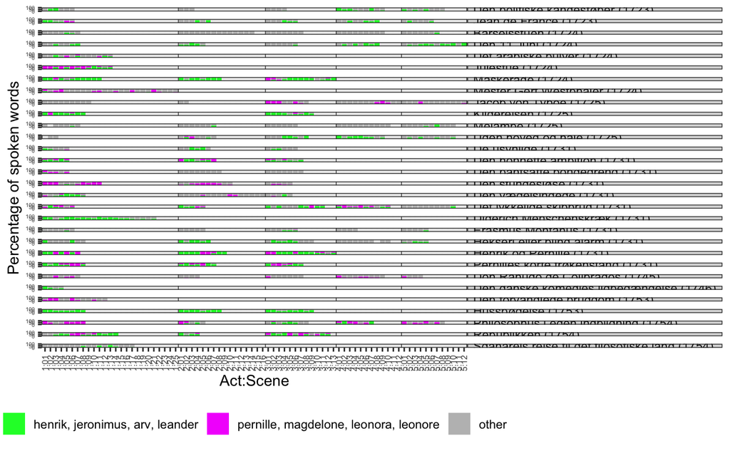

```r
  ggplot(df, aes(fill = group, y = percent_sum, x = act_scene)) +
    geom_bar(stat="identity") +
  scale_fill_manual(breaks = c(groups_used[length(groups_used):1], "other"),
                    values = c(my_colors, "grey")) +
  xlab("Act:Scene") +
  ylab("Percentage of spoken words") +
  facet_grid(rows = vars("title_year" = title_year),
             switch = "x") +
  scale_y_continuous(breaks = c(0, 50, 100)) +
  geom_vline(xintercept = intercepts, size = 0.2) +
  theme_bw() +
  theme(legend.position = "bottom",
          legend.title = element_blank(),
          axis.text.x = element_text(angle = 90, size = 6, hjust = 0, vjust = 0.5),
          axis.text.y = element_text(size = 4),
          strip.text.y = element_text(angle = 0, hjust = 0))
```

Make a plot like the one above, but now it shows percentage of words spoken in the whole play and not just one particular scene. A df is prepared again, and the plot is drawn.

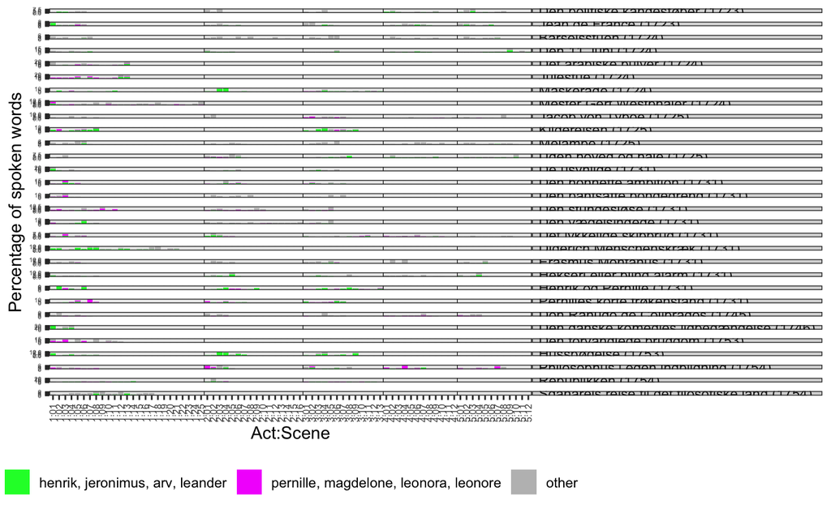

```r
df <- allplays %>%

  # Remove rows that are not dialogue
  filter(act != "", scene != "", speaker != "", !is.na(speaker), !is.na(spoke)) %>%

  # Keep only plays of interest
  filter(docTitle %in% my_plays) %>%

  # Add the number of spoken words
  mutate(n_spoken_words = str_count(spoke, '\\w+')) %>%

  # Organize dataset by grouping
  group_by(year, title_year, act_number, scene_number, speaker) %>%

  # Sum the words spoken by each speaker
  summarise(words = sum(n_spoken_words))

# Find highest number of scenes within each act for use in the plot
intercepts <- df %>% group_by(act_number) %>%
  summarise(max_scene = max(scene_number)) %>%
  mutate(intercepts = cumsum(max_scene+c(0.5,rep(0,length(act_number)-1)))) %>%
  pull(intercepts)

# Make order of plays chronological
play_chronology <- unique(df$title_year)
df$title_year <- factor(df$title_year, levels = play_chronology)

df <- df %>%
  # Calculate percentage of words spoken in each scene
  group_by(title_year) %>% mutate(percent = 100*(words/sum(words))) %>% ungroup() %>%

  # Add act:scene column
  mutate(act_scene = paste0(act_number, ":", str_pad(scene_number, 2, pad = "0")))

# Make group names into text that can be showed in the plot legend
for (i in 1:12){
  text <- paste(eval(parse(text = paste0("group", i))), collapse = ", ")
  assign(paste0("group", i, "text"), text)
}

# Make a column that indicates group
df$group <- "other"

for (i in 1:12){
  df$group <- ifelse(df$speaker %in% eval(parse(text = paste0("group", i))) & df$group=="other", eval(parse(text = paste0("group", i, "text"))), df$group)
}

groups_used <- c(group12text, group11text, group10text, group9text, group8text, group7text, group6text, group5text, group4text, group3text, group2text, group1text) %>% as_tibble() %>% filter(value != "") %>% pull(value)

df$group <- factor(df$group, levels = c("other", groups_used))

# If two characters from the same group speak in the same scene, their percentages should be added
df <- df %>% group_by(title_year, act_scene, group) %>%
   summarise(percent_sum = sum(percent))

# PLOTTING
ggplot(df, aes(fill = group, y = percent_sum, x = act_scene)) +
  geom_bar(stat="identity") +
  scale_fill_manual(breaks = c(groups_used[length(groups_used):1], "other"),
                    values = c(my_colors, "grey")) +
  xlab("Act:Scene") +
  ylab("Percentage of spoken words") +
  facet_grid(rows = vars("title_year" = title_year),
             switch = "x", scales = "free_y") +
  #scale_y_continuous(breaks = c(0, 50, 100)) +
  geom_vline(xintercept = intercepts, size = 0.2) +
  theme_bw() +
  theme(legend.position = "bottom",
          legend.title = element_blank(),
          axis.text.x = element_text(angle = 90, size = 6, hjust = 0, vjust = 0.5),
          axis.text.y = element_text(size = 4),
          strip.text.y = element_text(angle = 0, hjust = 0))
```

```r
ggsave(here("graphs/word-percentage-plots2", "vis-word-percent-plot-GENDER.pdf"),
       width = 297,
       height = 210,
       units = "mm")
```

Make a plot like the one above but now, the group “other” differentiates between social classes. This requires the social class data to be combined with allplays before hand.

[figure not shown]

```r
# Load social class data
social <- read_excel(here("gender AND Mask_alaw sammenlagte karakterer reduceret i kategoriantal.xlsx"))
social <- unite(data = social, col = "social_status", "social status, main character", "social status, other characters", sep="", na.rm = TRUE) %>%
  mutate(social_status = gsub("^NA", "", social_status)) %>%
  mutate(social_status = gsub("NA$", "", social_status))

# Combine with allplays
allplays <- allplays %>%
  mutate(docTitle = tolower(docTitle)) %>%
  left_join(social[,c(1,2,7)], by = c("docTitle"="play", "speaker"="speaker"))

# Decapitalize my_plays
my_plays <- unique(allplays$docTitle[allplays$speaker %in% my_speakers])

# PREPARE THE TABLE
df <- allplays %>%

  # Remove rows that are not dialogue
  filter(act != "", scene != "", speaker != "", !is.na(speaker), !is.na(spoke)) %>%

  # Keep only plays of interest
  filter(docTitle %in% my_plays) %>%

  # Add the number of spoken words
  mutate(n_spoken_words = str_count(spoke, '\\w+')) %>%

  # Organize dataset by grouping
  group_by(year, title_year, act_number, scene_number, speaker, social_status) %>%

  # Sum the words spoken by each speaker
  summarise(words = sum(n_spoken_words))

# Find highest number of scenes within each act for use in the plot
intercepts <- df %>% group_by(act_number) %>%
  summarise(max_scene = max(scene_number)) %>%
  mutate(intercepts = cumsum(max_scene+c(0.5,rep(0,length(act_number)-1)))) %>%
  pull(intercepts)

# Make order of plays chronological
play_chronology <- unique(df$title_year)
df$title_year <- factor(df$title_year, levels = play_chronology)

df <- df %>%
  # Calculate percentage of words spoken in each scene
  group_by(title_year) %>% mutate(percent = 100*(words/sum(words))) %>% ungroup() %>%

  # Add act:scene column
  mutate(act_scene = paste0(act_number, ":", str_pad(scene_number, 2, pad = "0")))

# Make group names into text that can be showed in the plot legend
for (i in 1:12){
  text <- paste(eval(parse(text = paste0("group", i))), collapse = ", ")
  assign(paste0("group", i, "text"), text)
}

# Make a column that indicates group
df$group <- ifelse(df$social_status=="", "Unknown", df$social_status)
statuses <- unique(df$social_status)

for (i in 1:12){
  df$group <- ifelse(df$speaker %in% eval(parse(text = paste0("group", i))) & df$social_status %in% statuses, eval(parse(text = paste0("group", i, "text"))), df$group)
}

groups_used <- c(group12text, group11text, group10text, group9text, group8text, group7text, group6text, group5text, group4text, group3text, group2text, group1text) %>% as_tibble() %>% filter(value != "") %>% pull(value)

statuses_used <- unique(df$group[!df$group %in% groups_used])

df$group <- factor(df$group, levels = c(statuses_used, groups_used))

# If two characters from the same group speak in the same scene, their percentages should be added
df <- df %>% group_by(title_year, act_scene, group) %>%
   summarise(percent_sum = sum(percent))

# PLOTTING
library(colorspace)

ggplot(df, aes(fill = group, y = percent_sum, x = act_scene)) +
  geom_bar(stat="identity") +
  scale_fill_manual(breaks = c(groups_used[length(groups_used):1], statuses_used),
                    values = c(my_colors, qualitative_hcl(length(statuses_used), palette = "Set 3"))) +
  xlab("Act:Scene") +
  ylab("Percentage of spoken words") +
  facet_grid(rows = vars("title_year" = title_year),
             switch = "x", scales = "free_y") +
  #scale_y_continuous(breaks = c(0, 50, 100)) +
  geom_vline(xintercept = intercepts, size = 0.2) +
  theme_bw() +
  theme(legend.position = "bottom",
          legend.title = element_blank(),
          axis.text.x = element_text(angle = 90, size = 6, hjust = 0, vjust = 0.5),
          axis.text.y = element_text(size = 4),
          strip.text.y = element_text(angle = 0, hjust = 0))
```

DET HER VIRKER:::::

[figure not shown]

To save a plot as a pdf file (which is preferable, since the quality of the plot will remain high when zooming in), run the function below which saves the last drawn plot in the specified location. If png format is preferred, simply change the file name extension from pdf to png.

```r
ggsave(here("graphs/word-percentage-plots_Max", "vis-word-percent-plot-Max.pdf"),
       width = 297,
       height = 210,
       units = "mm")
```